# R Notebook

```r
library(deSolve)
library(tidyverse)
```

# Model

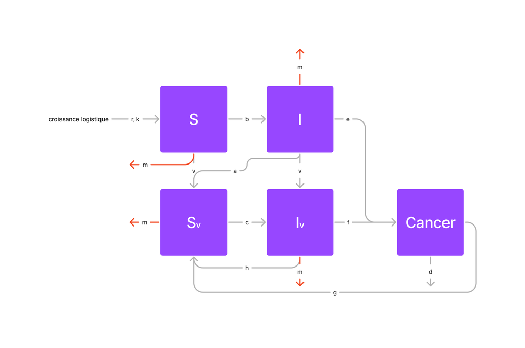

Les variables :

- $S$ : Nombre d’individus sains n’ayant pas été vaccinés dans la population
- $S_v$ : Nombre d’individus sains vaccinés
- $I$ : Nombre de personnes non-vaccinées infectées par le papillomavirus humain
- $I_v$ : Nombre de personnes vaccinées infectées par le papillomavirus humain
- $C$ : Nombre de personnes pour lesquelles l’infection évolue en cancer du col de l’utérus.

Les paramètres :

- $r$, $k$ : r est le taux de reproduction et k la capacité d’accueil (ici de la population humaine) dans le cadre d’une croissance logistique suivie par la population (mortalité et naissance indépendantes du cancer).
- $m$ : taux de mortalité naturelle (sans influence du cancer)
- $d$ : taux de mortalité due au cancer du col de l’utérus
- $v$ : taux de vaccination
- $b$, $c$ : taux d’infection par le papillomavirus humain des personnes saines (b) et des personnes saines vaccinées (c)
- $e$, $f$ : taux d’évolution de l’infection en cancer chez les infectés (e) et les infectés vaccinés (f)
- $a$, $h$ : taux de guérison de l’infection sans cancer pour les infectés (a) et les infectés vaccinés (h)
- $g$ : taux de guérison du cancer du col de l’utérus

```r
time_vector <- seq(0, 100, 0.25)
init <- c(S = 0, I = 1, Sv = 9999, Iv = 0, C = 0)
params <- c(
  # croissance logistique :
  r = 1.2,
  k = 10000,

  # taux de mortalité: ok
  m = 0.0097, # mort naturel
  d = 0.047, # mort par cancer TBD

  # taux de contamination:
  b = 4e-4, # non vacciné
  c = 1e-4, # vacciné

  # taux de vaccination:
  v = 0.04,

  # taux de guérison:
  a = 0.07, # non vacciné
  h = 0.09, # vacciné

  # taux de cancer: ok
  e = 0.08, # non vacciné
  f = 0.02, # vacciné

  # taux guérison cancer
  g = 0.5
)

logisticFunction <- function(N, r, k) {
  N * r * (1 - N / k)
}

modeleSIC <- function(t, y, params) {
  with(as.list(c(y, params)), {
    dS <- logisticFunction(S + I + Iv + Sv + C, r, k) -
      v * S -
      b * S * I
    dI <- b * S * I - (a + e + v) * I
    dSv <- v * S + a * I + h * Iv + g * C -
      c * Sv * Iv

    dIv <- v * I + c * Sv * Iv - (h + f) * Iv
    dC <- e * I + f * Iv - (d + g) * C
    return(list(c(dS, dI, dSv, dIv, dC)))
  })
}
```

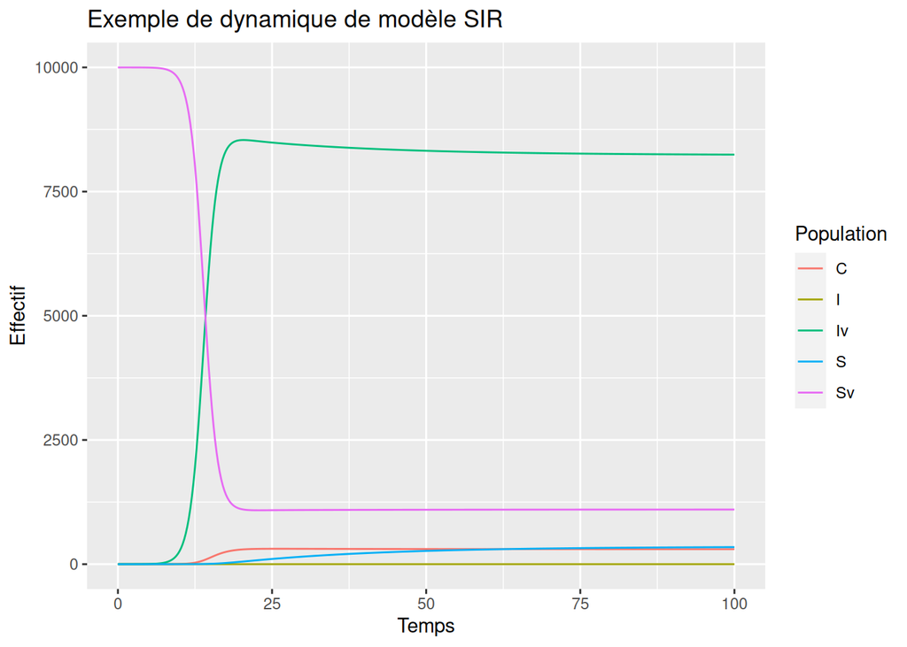

```r
results <- as.data.frame(lsoda(init, time_vector, modeleSIC, params))

results %>%
  pivot_longer(!time, names_to = "pop", values_to = "N") %>%
  ggplot() +
  geom_line(aes(x = time, y = N, color = pop)) +
  labs(y = "Effectif", x = "Temps",
       title = "Exemple de dynamique de modèle SIR",
       color = "Population")
```

```r
results
```

```
##       time            S            I       Sv           Iv            C
## 1     0.00 0.000000e+00 1.000000e+00 9999.000 0.000000e+00   0.00000000
## 2     0.25 1.032095e-05 9.536105e-01 9999.017 1.094785e-02   0.01827110
## 3     0.50 7.374374e-05 9.093730e-01 9999.033 2.411585e-02   0.03341656
## 4     0.75 2.218077e-04 8.671876e-01 9999.046 4.008053e-02   0.04588737
## 5     1.00 4.692581e-04 8.269592e-01 9999.056 5.956052e-02   0.05607758
## 6     1.25 8.195639e-04 7.885970e-01 9999.061 8.345446e-02   0.06433235
## 7     1.50 1.269471e-03 7.520145e-01 9999.061 1.128821e-01   0.07095653
## 8     1.75 1.811240e-03 7.171290e-01 9999.054 1.492418e-01   0.07622004
## 9     2.00 2.434878e-03 6.838618e-01 9999.037 1.942781e-01   0.08036410
## 10    2.25 3.129559e-03 6.521380e-01 9999.008 2.501722e-01   0.08360704
## 11    2.50 3.884306e-03 6.218858e-01 9998.966 3.196459e-01   0.08614915
## 12    2.75 4.688845e-03 5.930371e-01 9998.905 4.060982e-01   0.08817813
## 13    3.00 5.534005e-03 5.655267e-01 9998.822 5.137746e-01   0.08987430
## 14    3.25 6.411923e-03 5.392925e-01 9998.712 6.479765e-01   0.09141601
```

[output cut: 387 more lines]

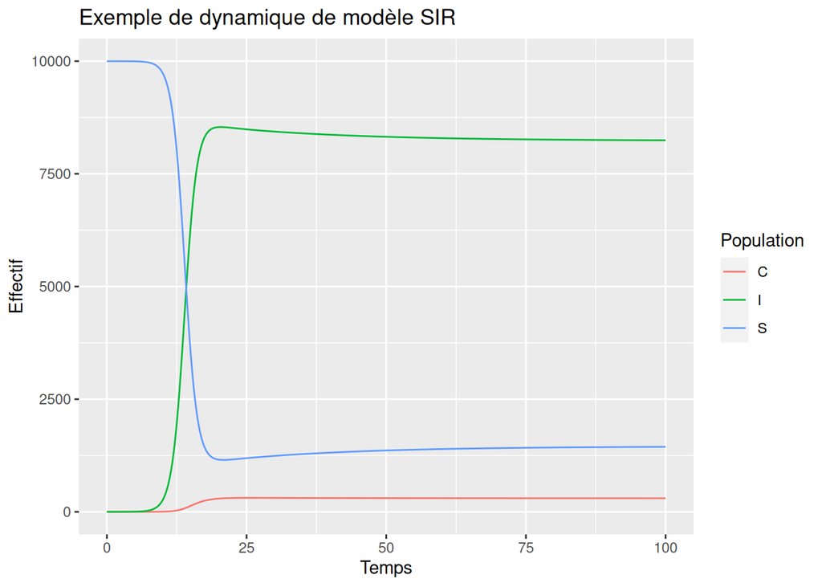

```r
results %>%
  transmute(time, S = S + Sv, I = I + Iv, C) %>%
  pivot_longer(!time, names_to = "pop", values_to = "N") %>%
  ggplot() +
  geom_line(aes(x = time, y = N, color = pop)) +
  labs(y = "Effectif", x = "Temps",
       title = "Exemple de dynamique de modèle SIR",
       color = "Population")
```

```r
results %>%
  group_by(time) %>%
  summarise(tot = sum(S, Sv, I, Iv, C), V = (Sv + Iv) / tot * 100, S = sum(S, Sv) / tot * 100, I = sum(I, Iv) / tot * 100, C = C / tot * 100)
```

```
## # A tibble: 401 × 6
##     time    tot     V     S       I        C
##    <dbl>  <dbl> <dbl> <dbl>   <dbl>    <dbl>
##  1  0    10000   100.  100. 0.01    0
##  2  0.25 10000.  100.  100. 0.00965 0.000183
##  3  0.5  10000.  100.  100. 0.00933 0.000334
##  4  0.75 10000.  100.  100. 0.00907 0.000459
##  5  1    10000.  100.  100. 0.00887 0.000561
##  6  1.25 10000.  100.  100. 0.00872 0.000643
##  7  1.5  10000.  100.  100. 0.00865 0.000710
##  8  1.75 10000.  100.  100. 0.00866 0.000762
##  9  2    10000.  100.  100. 0.00878 0.000804
## 10  2.25 10000.  100.  100. 0.00902 0.000836
## # … with 391 more rows
```